# Simulation of Structural Topic Model

Mengbing Li

March 29, 2019

Reference: Roberts et. al. JASA (2016)

We would like to reproduce the simulation example in the original paper.

The number of topics $K = 3$ over $D = 100$ documents, containing a total of $V = 50$ unique words.

The covariate associated with each document $d = 1, \ldots, D$ is $\mathbf{x}_d \sim \mathrm{Uniform} (0,1)$. The number of words in each document $N_d \sim \mathrm{Poisson} (50)$ independently.

The distribution of the $n$-th word in document $d$ is $\mathbf{w}_{d,n} \sim \mathrm{Multinomial}_V (\mathbf{B} \mathbf{\theta}_d)$, where we omit the token level latent variable $\mathbf{z}$ to reduce sampling variance.

## Generate simulated corpus data

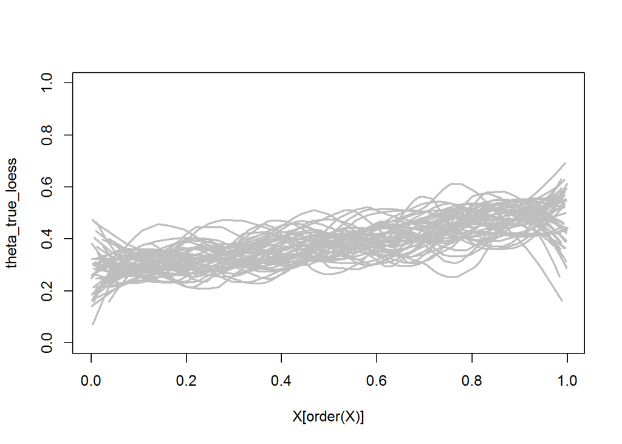

```r
# simulate the corpus data n.sim times
n.sim <- 50

# number of topics
K <- 3
# number of documents
D <- 100
# number of volcabulary
V <- 50

# number of words in each document
Nd_means <- 50

# Labels
documents_names <- paste("Document", 1:D)
topics_names <- paste("Topic", 1:K)
terms_names <- paste("Term", 1:V, sep = "")

# initialize the matrix to store posterior samples of theta
theta_sample_stm <- matrix(0, nrow = D, ncol = n.sim)
theta_sample_stm_loess <- matrix(0, nrow = D, ncol = n.sim)
theta_true <- matrix(0, nrow = D, ncol = n.sim)
theta_true_loess <- matrix(0, nrow = D, ncol = n.sim)

for(sim.time in 1:n.sim){

  set.seed(2019+sim.time)

  N <- rpois(D, Nd_means)

  # covariates for each document
  X <- runif(D, 0, 1)

  ## Generate latent topic and term distributions
  # "True" Document/Topic distribution matrix
  mu <- cbind(0.5, cos(10*X))
  Sigma_true <- 0.5*diag(K-1)

  theta <- matrix(0, nrow = D, ncol = ncol(mu) +1)
  for(d in 1:D){
    eta <- c(mvrnorm(1, mu[d,], Sigma_true),0)

    # log-sum-exp trick to prevent underflow
    max_eta <- max(eta)
    log_sum_exp_eta <- max_eta + log(sum(exp(eta - max_eta)))
    theta[d, ] <- exp(eta - log_sum_exp_eta)
  }

  # set the last topic parameter to 0
  # theta <- cbind(theta, 0)
  colnames(theta) <- topics_names
  rownames(theta) <- documents_names

  # "True" Topic/Term Distribution Matrix
  B <- array(0, dim = c(K, V, D))
  for(d in 1:D){
    for(k in 1:K){
      B[k, , d] <- rdirichlet(1, rep(0.05, V))
    }
  }
  dimnames(B)[[3]] <- documents_names
  dimnames(B)[[1]] <- topics_names
  dimnames(B)[[2]] <- terms_names


  # generate documents
  documents <- c()
  for(d in 1:D){
    # topic-word joint probabilities
    topic_term_prob <- t(B[,,d])%*%theta[d,]
    document <- c()
    for(n in 1:N[d]){
      document <- c(document, sample(terms_names, 1, prob = topic_term_prob))
    }
    documents <- rbind(documents, paste(document, sep = " ", collapse = " "))
  }
  rownames(documents) <- documents_names
  colnames(documents) <- "documents"


  mydata <- data.frame(ind = 1:D,
                       documents = documents,
                       X = X)



  ### Process the corpus data -------------------------------------------------------------------

  #' textProcessor: Function that takes in a vector of raw texts and performs
  #' basic operations. This function is essentially a wrapper tm package
  #' where various user specified options can be selected.
  # processedDocuments <- textProcessor(mydata$documents, metadata = mydata,
  #                                     removenumbers = FALSE)
  # # str(processedDocuments)
  #
  # #' prepDocuments: Performs several corpus manipulations including removing
  # #' words and renumbering word indices (to correct for zero-indexing and/or
  # #'  unusued words in the vocab vector). Also removes infrequent terms
  # #'  depending on the user-set parameter lower.thresh
  # out <- prepDocuments(processedDocuments$documents, processedDocuments$vocab,
  #                      processedDocuments$meta, lower.thresh = 15)
  #
  #
  #
  # ### Run the model -----------------------------------------------------------------------------
  # # we use the correctly specified K, and B-spline with 10 degrees of freedom for the covariate
  # fit <- stm(documents = out$documents, vocab = out$vocab,
  #            K = K, prevalence =~ s(X),
  #            max.em.its = 75, data = out$meta,
  #            init.type = "Spectral")
  #
  # # estimateEffect: simulates a set of parameters which can then be plotted.
  # # If there are multiple variables specified in estimateEffect, then all other
  # # variables are held at their sample median.
  # prep <- estimateEffect(c(2) ~ s(X), fit, metadata = out$meta, nsims = 1)
  # plot(prep, "X", method = "continuous")




  ### 2. Estimated true theta with sampling variance ----------------------------------
  # we run simple linear regression on mu_2 = gamma_2^\top X. After obtaining the estimate of gamma_2, we compute the estimated \mu_2 and theta_2

  X_order <- order(X)

  # create linear regression data
  lm_data <- mydata[X_order,]
  lm_data$eta_1 <- 0
  lm_data$eta_2 <- 0
  for(d in 1:D){
    mu_d <- c(0.5, lm_data$X[d])
    lm_data[d, c("eta_1", "eta_2")] <- mvrnorm(1, mu_d, Sigma_true)
  }
  lm_data$eta_3 <- 0
  lm_fit <- lm(eta_2 ~ s(X), data = lm_data)
  lm_data$mu_hat <- lm_fit$fitted.values
  # lm_data$theta_est <- apply(cbind(0.5, lm_data[, c("mu_hat", "eta_3")]), 1, function(x) exp(x) / sum(exp(x)))[2,]
  lm_data$theta_est <- apply(lm_data[, c("eta_1", "mu_hat", "eta_3")], 1, function(x) exp(x) / sum(exp(x)))[2,]
  theta_true_loess <- loess(theta_est ~ X, data=lm_data, span=1/3)$fitted

  if(sim.time==1){
    plot(x = X[order(X)], y = theta_true_loess, type="l", col="grey", lwd = 2, ylim=0:1)
  }
  else{
    lines(x = X[order(X)], y = theta_true_loess, col="grey", lwd = 2)
  }




  # ### True theta values with sampling variance -----------------------------------
  # mu_true_sample <- cbind(rep(0.5, D), cos(10*X_sorted), 0)
  # eta_true_sample <- mvrnorm(n.sim, mu_true_sample, Sigma_true)
  # theta_true <- apply(mu_true, 1, function(x) exp(x) / sum(exp(x)))
  # # calculate the loess estimate of theta[2]
  # # theta_true_sorted <- theta_true[2,][order(X, decreasing=FALSE)]
  # loess_data <- data.frame(theta = theta_true[2,], X = X_sorted)
  # theta_true_loess[,sim.time] <- loess(theta ~ X, data=loess_data, span=1/3)$fitted

}
```

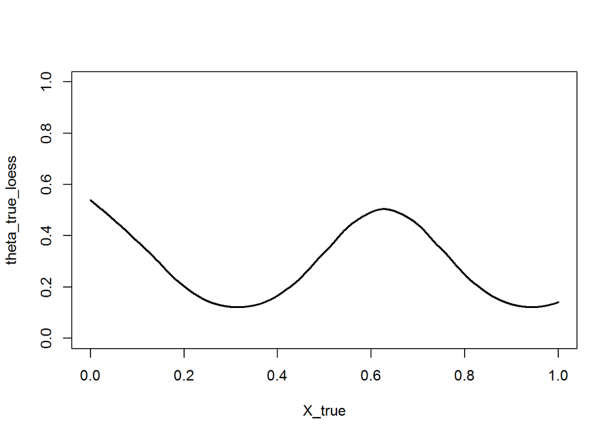

```r
### To plot the black curve in the paper
### True theta with no sampling variance
X_true <- seq(0,1,length.out = 1000)
mu_true <- cbind(rep(0.5, D), cos(10*X_true), 0)
theta_true <- apply(mu_true, 1, function(x) exp(x) / sum(exp(x)))
# calculate the loess estimate of theta[2]
loess_data <- data.frame(theta = theta_true[2,], X = X_true)
theta_true_loess <- loess(theta ~ X, data=loess_data, span=1/3)$fitted

plot(x = X_true, y = theta_true_loess, type="l", col="black", lwd = 2, ylim=0:1)
```

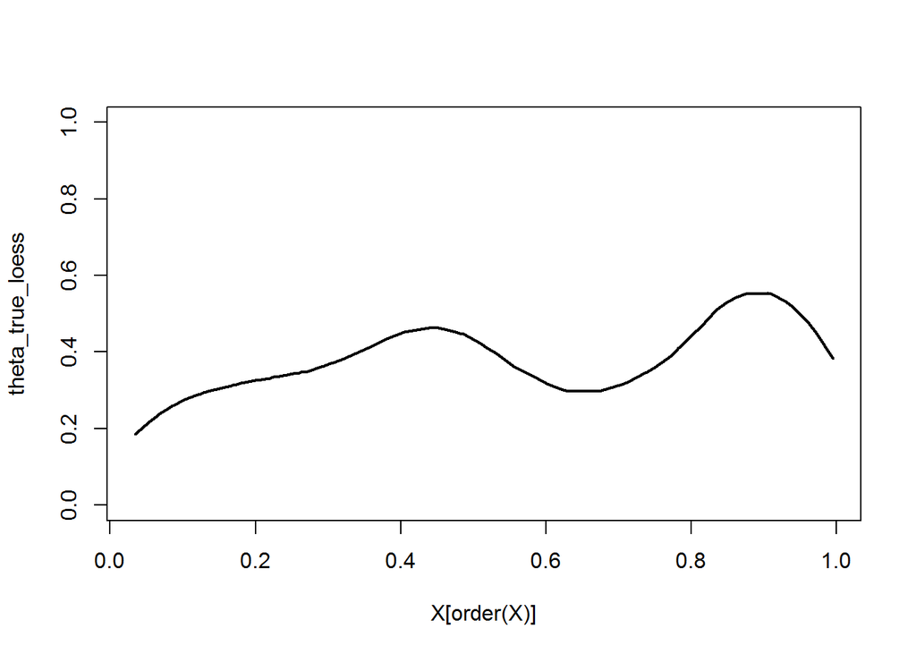

```r
### Estimated true theta with sampling variance ----------------------------------
# we run linear regression on mu_2 = gamma_2^\top X. After obtaining the estimate of
# gamma_2, we compute the estimated \mu_2 --> theta_2

X_order <- order(X)
lm_data <- mydata[X_order,]
lm_data$eta_1 <- 0
lm_data$eta_2 <- 0
for(d in 1:D){
  mu_d <- c(0.5, lm_data$X[d])
  lm_data[d, c("eta_1", "eta_2")] <- mvrnorm(1, mu_d, Sigma_true)
}
lm_data$eta_3 <- 0
lm_fit <- lm(eta_2 ~ s(X[order(X)]), data = lm_data)
lm_data$mu_hat <- lm_fit$fitted.values
# lm_data$theta_est <- apply(cbind(0.5, lm_data[, c("mu_hat", "eta_3")]), 1, function(x) exp(x) / sum(exp(x)))[2,]
lm_data$theta_est <- apply(lm_data[, c("eta_1", "mu_hat", "eta_3")], 1, function(x) exp(x) / sum(exp(x)))[2,]
theta_true_loess <- loess(theta_est ~ X[order(X)], data=lm_data, span=1/3)$fitted


plot(x = X[order(X)], y = theta_true_loess, type="l", col="black", lwd = 2, ylim=0:1)
```

## Trying something else:

this was not how the paper generated Figure 2

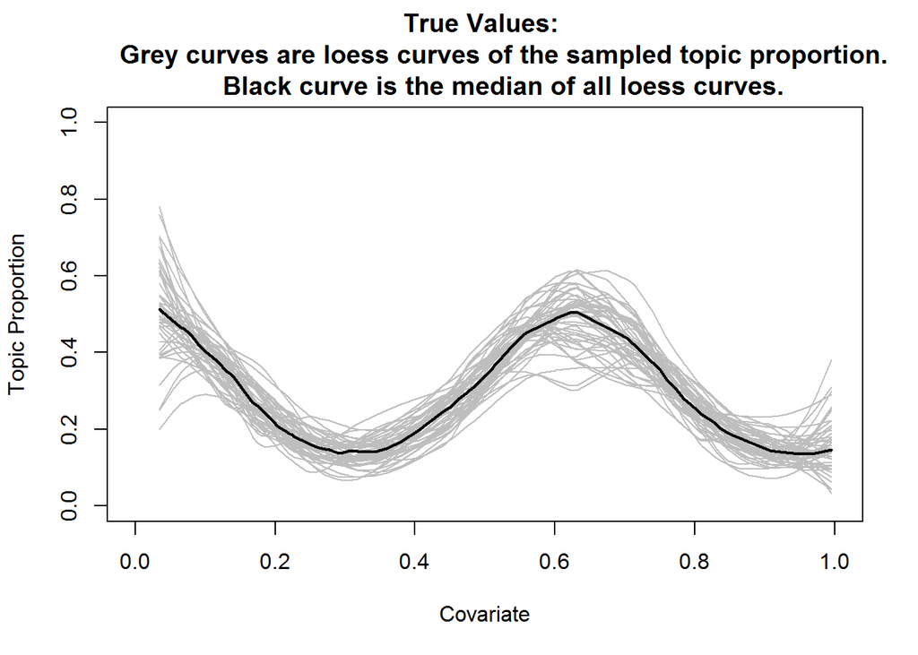

```r
# plot the true topic proportion of topic 2 vs covariate values -------------------
### but this was not how the paper generated Figure 2
nx <- 100
X_sorted <- sort(X)
X_true <- X_sorted
mu_true <- cbind(rep(0.5, D), cos(10*X_true))
theta_true <- apply(mu_true, 1, function(x) exp(x) / sum(exp(x)+1))
# plot(x = NULL, y = NULL, xlim = c(0,1),
#   # x = X_true, y = theta_true[2,], type = "l",
#      ylim = c(0,1))
# lines(loess(theta_true[2,] ~ X_true, f=1/3), col="black")


### plot the sampled topic distributions
# we will plot the loess curve with span = 1/3 and the median of the
# sampled loess curves
# create a frame of plot without points
# pdf("stm_simulation_OriginalPaper_Figure2.3_TrueTopicProp.pdf",
#     width = 10, height = 10)

plot(x = NULL, y = NULL,
     xlim = c(0,1), ylim = c(0,1),
     main = "True Values:
     Grey curves are loess curves of the sampled topic proportion.
     Black curve is the median of all loess curves.",
     xlab = "Covariate", ylab = "Topic Proportion")

n.sim <- 50
theta_sample <- matrix(0, nrow = nx, ncol = n.sim)
theta_sample_loess <- matrix(0, nrow = nx, ncol = n.sim)
for(j in 1:n.sim){
  for(i in 1:nx){
    eta_sample <- c(mvrnorm(n=1, mu = mu_true[i,], Sigma = Sigma_true),0)
    theta_sample[i,j] <- exp(eta_sample[2]) / sum(exp(eta_sample))
  }
  loess_data <- data.frame(theta = theta_sample[,j], X = X_true)
  theta_sample_loess[,j] <- loess(theta ~ X, data = loess_data, span=1/3)$fitted
  lines(x = X_true, y = theta_sample_loess[,j], col="grey")
}

theta_sample_median <- apply(theta_sample_loess, 1, median)
lines(x = X_true, y = theta_sample_median, col="black", lwd = 2)
```

```r
# dev.off()
```